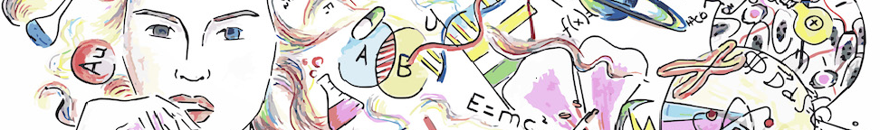

# ACTIVIDADES CENTROS11F

¿Organizáis actividades internamente en vuestro centro educativo para celebrar el [Día de la Mujer y la Niña en la Ciencia](https://11defebrero.org/)? Entonces sois un Centro11F.

Consulta nuestras secciones de [materiales](https://11defebrero.org/materiales/) e ideas [#Enclase11F](https://11defebrero.org/centros-educativos/ideas-enclase11f/) si quieres más fuentes de inspiración o material para usar en tus aulas.

Si tenéis ya todo organizado, podéis comunicárnoslo a través del formulario que encontrarás en [este enlace](https://11defebrero.org/quieres-anunciar-una-charla-o-actividad/).

Si tenéis dudas, podéis mirar la sección de [preguntas frecuentes](https://11defebrero.org/preguntas-frecuentes/).

Si detectas algún error en estos datos, por favor, escribe a: correccionesweb11F@gmail.com

### [Ver todas](https://11defebrero.github.io/web11F/centros11F_todos.html#detalles)

### Mapa Centros11F

En este mapa interactivo puedes consultar las actividades programadas por los centros educativos. Si pinchas en cualquier icono podrás acceder a más información sobre cada actividad.

[interactive chart not shown]

(Nota: la localización de algunos centros en el mapa es aproximada)

### Tabla Centros11F

En esta tabla podéis consultar las actividades programadas por los centros educativos por provincia, municipio, tipo de actividad, etc. Podéis filtrar por varios criterios desde la fila superior (aparecerá una **X** en las columnas que tengan el filtro activado).

Si pincháis en el nombre del centro podréis acceder a más información útil.

| Provincia | Municipio | Centro | Tipo actividad | Título |
| --- | --- | --- | --- | --- |
| A Coruña | A CORUÑA | IES MONTE DAS MOAS | Proyecto | Criptogame |
| A Coruña | A CORUÑA | IES RAFAEL DIESTE | Exposición, charla y proyección | "A ciencia ten nome de muller" |
| A Coruña | A CORUÑA | IES RAMÓN MENÉNDEZ PIDAL | Exposición, Diseño de infografías y líneas del tiempo interactivas | Exposiciones y actividades varias |
| A Coruña | AMES | IES DE AMES | Exposición | Exposición "Con A de astrónomas" |
| A Coruña | FERROL | COMPAÑÍA DE MARÍA - FERROL | Taller, Tutorías Secundaria | A ciencia non distingue de xénero |
| A Coruña | SANTIAGO DE COMPOSTELA | INSTITUTO PLURILINGÜE ROSALÍA DE CASTRO | MESA REDONDA | Mulleres e nenas na Ciencia |
| Alicante/Alacant | ELDA | IES LA MELVA | Exposición | Exposición de carteles sobre Científicas hechos por el alumnado de 2ºESO |
| Alicante/Alacant | ELDA | IES LA MELVA | Concurso de vídeos | Concurso de Vídeos |
| Alicante/Alacant | PETRER | IES AZORÍN | Conjunto de actividades varias | "Las científicas existen" |
| Almería | ADRA | IES GAVIOTA | Taller | Científicas ocultas |

[output cut: 164 more lines]

Última actualización: 2019-02-18